# DATA Assessment 2023-24

## Department of Computer Science, University of York

### DATA: Introduction to Data Science

## Task 1: Domain Analysis (5 marks)

Given the business domain and the data overview presented (in the assessment paper), provide a brief description of

- the business problem and its significance to the relevant sector;
- the link between the business problem and the field of data science;
- the main areas of investigation; and
- potential ideas and solutions.

**Word Limit:** 300 words

The business problem facing this bank within the financial sector revolves around enhancing customer service, and reducing the risk when offering services such as loans and credit cards and enabling informed decision-making.

The significance lies in leveraging data to understand client behaviour to minimise these risks associated with financial transactions. This not only ensures better customer satisfaction but also contributes to the bank's competitiveness within the industry.

The link between this problem and data science is large. Data science is the ability to gain meaningful insights from vast and diverse sets of data. It enables the business to explore avenues to comprehend client behaviour, assess risks, and predict outcomes by using processes such as predictive modelling.

Key areas of investigation include customer segmentation: Using data such as demographics and transactional behavior to segment customers and tailor different services for them. Risk assessment: Looking at past transactional data to look at the risks associated with each customer.

Potential solutions involve deploying models and perhaps sending out personalised marketing campaigns to consumers who are going to be affected by them. It can also be used to use early warning systems for the bank if a customer is going towards a high-risk model. We could potentially introduce a system that enhances the customer experience. Such as loan approval models and issuing credit cards. This will help the bank minimize its risk and make very informed decisions leading to a better business model and better decision making through the use of data science.

## Task 2: Database Design (25 marks)

Having understood the business domain, present a conceptual design in the form of an entity-relationship (ER) model that would be helpful in creating a database for the bank.

The bank data currently exists in the form of a csv file called *BankRecords.csv*, provided on VLE (path given in page 5, assessment paper). This file has all the existing records. The table available in the csv file is unnormalised. The information about its different columns is given in Tables 1 and 2 (in the assessment paper).

Following the standard principles of database normalisation, normalise the given table (*BankRecords.csv*) to a database schema that has minimum redundancies. Then, using the designed schema, create an SQLite database.

Your answer should include the SQL statements needed to accomplish this step. Your submission should also include the created SQLite database file.

Your answer should clearly cover the following:

- Any assumptions you are making about the given scenario;
- The designated keys, existing relationships, and identified functional dependencies;
- The steps followed and justifications for the decisions made.

**World Limit**: 500 words. This limit applies only to the explanations. There is no limit on any associated code/SQL statements or figures.

**Write your answer here (text cell(s) to be used, as appropriate)**

#### ER Model

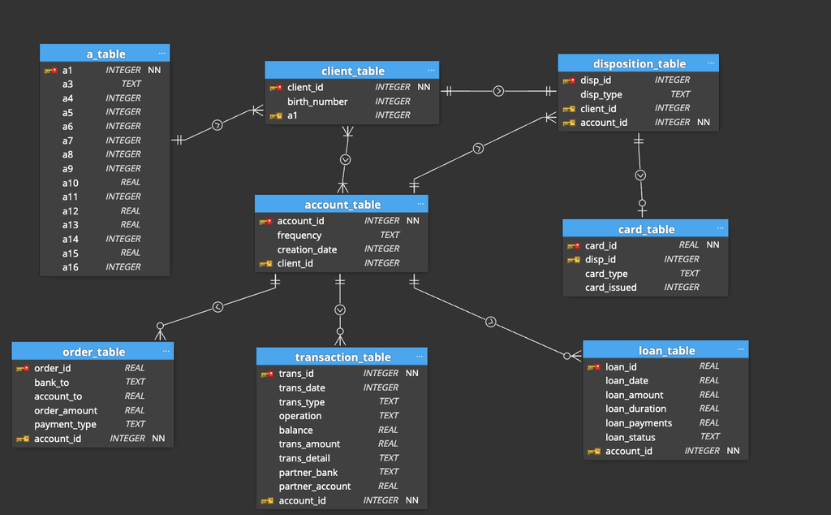

```python
import pandas as pd
import numpy as np

file = "BankRecords.csv"
df = pd.read_csv(file, low_memory = False)
df
```

|  | account_id | frequency | creation_date | loan_id | loan_date | loan_amount | loan_duration | loan_payments | loan_status | order_id | ... | a7 | a8 | a9 | a10 | a11 | a12 | a13 | a14 | a15 | a16 |
| --- | --- | --- | --- | --- | --- | --- | --- | --- | --- | --- | --- | --- | --- | --- | --- | --- | --- | --- | --- | --- | --- |
| 0 | 1 | Monthly | 950324 | NaN | NaN | NaN | NaN | NaN | NaN | 29401.0 | ... | 2 | 1 | 4 | 65.3 | 8968 | 2.83 | 3.35 | 131 | 1740.0 | 1910 |
| 1 | 1 | Monthly | 950324 | NaN | NaN | NaN | NaN | NaN | NaN | 29401.0 | ... | 2 | 1 | 4 | 65.3 | 8968 | 2.83 | 3.35 | 131 | 1740.0 | 1910 |
| 2 | 1 | Monthly | 950324 | NaN | NaN | NaN | NaN | NaN | NaN | 29401.0 | ... | 2 | 1 | 4 | 65.3 | 8968 | 2.83 | 3.35 | 131 | 1740.0 | 1910 |
| 3 | 1 | Monthly | 950324 | NaN | NaN | NaN | NaN | NaN | NaN | 29401.0 | ... | 2 | 1 | 4 | 65.3 | 8968 | 2.83 | 3.35 | 131 | 1740.0 | 1910 |
| 4 | 1 | Monthly | 950324 | NaN | NaN | NaN | NaN | NaN | NaN | 29401.0 | ... | 2 | 1 | 4 | 65.3 | 8968 | 2.83 | 3.35 | 131 | 1740.0 | 1910 |
| ... | ... | ... | ... | ... | ... | ... | ... | ... | ... | ... | ... | ... | ... | ... | ... | ... | ... | ... | ... | ... | ... |
| 2243453 | 11382 | Monthly | 950820 | NaN | NaN | NaN | NaN | NaN | NaN | NaN | ... | 0 | 1 | 1 | 100.0 | 10673 | 4.75 | 5.44 | 100 | 18782.0 | 18347 |
| 2243454 | 11382 | Monthly | 950820 | NaN | NaN | NaN | NaN | NaN | NaN | NaN | ... | 0 | 1 | 1 | 100.0 | 10673 | 4.75 | 5.44 | 100 | 18782.0 | 18347 |
| 2243455 | 11382 | Monthly | 950820 | NaN | NaN | NaN | NaN | NaN | NaN | NaN | ... | 0 | 1 | 1 | 100.0 | 10673 | 4.75 | 5.44 | 100 | 18782.0 | 18347 |
| 2243456 | 11382 | Monthly | 950820 | NaN | NaN | NaN | NaN | NaN | NaN | NaN | ... | 0 | 1 | 1 | 100.0 | 10673 | 4.75 | 5.44 | 100 | 18782.0 | 18347 |
| 2243457 | 11382 | Monthly | 950820 | NaN | NaN | NaN | NaN | NaN | NaN | NaN | ... | 0 | 1 | 1 | 100.0 | 10673 | 4.75 | 5.44 | 100 | 18782.0 | 18347 |

2243458 rows × 46 columns

```python
client_table = df[['client_id', 'birth_number', 'a1' ]].drop_duplicates()
client_table = client_table.dropna(subset=['client_id'])
client_table
```

|  | client_id | birth_number | a1 |
| --- | --- | --- | --- |
| 0 | 1 | 706213 | 18 |
| 239 | 2 | 450204 | 1 |
| 240 | 3 | 406009 | 1 |
| 2151 | 4 | 561201 | 5 |
| 2152 | 5 | 605703 | 5 |
| ... | ... | ... | ... |
| 2239135 | 13955 | 456030 | 1 |
| 2239136 | 13956 | 430406 | 1 |
| 2240351 | 13968 | 680413 | 61 |
| 2241485 | 13971 | 626019 | 67 |
| 2243205 | 13998 | 535812 | 74 |

5369 rows × 3 columns

```python
account_table = df[['account_id', 'frequency', 'creation_date', 'client_id' ]].drop_duplicates()
account_table.drop_duplicates(subset='account_id', keep='first', inplace=True)
account_table = account_table.dropna(subset=['account_id'])
account_table
```

|  | account_id | frequency | creation_date | client_id |
| --- | --- | --- | --- | --- |
| 0 | 1 | Monthly | 950324 | 1 |
| 239 | 2 | Monthly | 930226 | 2 |
| 2151 | 3 | Monthly | 970707 | 4 |
| 2853 | 4 | Monthly | 960221 | 6 |
| 3225 | 5 | Monthly | 970530 | 7 |
| ... | ... | ... | ... | ... |
| 2238767 | 11333 | Monthly | 940526 | 13931 |
| 2239135 | 11349 | Weekly | 950526 | 13955 |
| 2240351 | 11359 | Monthly | 941001 | 13968 |
| 2241485 | 11362 | Monthly | 951014 | 13971 |
| 2243205 | 11382 | Monthly | 950820 | 13998 |

4500 rows × 4 columns

```python
disposition_table = df[['disp_id', 'disp_type', 'account_id' , 'client_id']].drop_duplicates()

duplicates = disposition_table[disposition_table.duplicated(subset='disp_id', keep=False)]

disposition_table = disposition_table.drop_duplicates(subset='disp_id', keep='first')

disposition_table = disposition_table.dropna(subset=['disp_id'])

disposition_table
```

|  | disp_id | disp_type | account_id | client_id |
| --- | --- | --- | --- | --- |
| 0 | 1 | OWNER | 1 | 1 |
| 239 | 2 | OWNER | 2 | 2 |
| 240 | 3 | DISPONENT | 2 | 3 |
| 2151 | 4 | OWNER | 3 | 4 |
| 2152 | 5 | DISPONENT | 3 | 5 |
| ... | ... | ... | ... | ... |
| 2239135 | 13647 | OWNER | 11349 | 13955 |
| 2239136 | 13648 | DISPONENT | 11349 | 13956 |
| 2240351 | 13660 | OWNER | 11359 | 13968 |
| 2241485 | 13663 | OWNER | 11362 | 13971 |
| 2243205 | 13690 | OWNER | 11382 | 13998 |

5369 rows × 4 columns

```python
card_table = df[['card_id', 'disp_id', 'card_type' , 'card_issued']].drop_duplicates()
card_table = card_table.dropna(subset=['card_id'])
card_table
```

|  | card_id | disp_id | card_type | card_issued |
| --- | --- | --- | --- | --- |
| 3555 | 1.0 | 9 | gold | 981016 00:00:00 |
| 6134 | 2.0 | 19 | classic | 980313 00:00:00 |
| 13405 | 3.0 | 41 | gold | 950903 00:00:00 |
| 13749 | 4.0 | 42 | classic | 981126 00:00:00 |
| 19357 | 5.0 | 51 | junior | 950424 00:00:00 |
| ... | ... | ... | ... | ... |
| 2228084 | 1230.0 | 13312 | classic | 980308 00:00:00 |
| 2231574 | 1233.0 | 13382 | classic | 960706 00:00:00 |
| 2231899 | 1234.0 | 13386 | classic | 971128 00:00:00 |
| 2232051 | 1239.0 | 13442 | junior | 980202 00:00:00 |
| 2240351 | 1247.0 | 13660 | classic | 950613 00:00:00 |

892 rows × 4 columns

```python
order_table = df[['order_id', 'account_id' , 'bank_to', 'account_to', 'order_amount', 'payment_type']].drop_duplicates()

order_table = order_table.dropna(subset=['order_id'])
order_table
```

|  | order_id | account_id | bank_to | account_to | order_amount | payment_type |
| --- | --- | --- | --- | --- | --- | --- |
| 0 | 29401.0 | 1 | YZ | 87144583.0 | 2452.0 | Household |
| 239 | 29403.0 | 2 | QR | 13943797.0 | 7266.0 | Household |
| 1195 | 29402.0 | 2 | ST | 89597016.0 | 3372.7 | Loan payment |
| 2151 | 29406.0 | 3 | AB | 59972357.0 | 3539.0 | Insurance payment |
| 2385 | 29405.0 | 3 | CD | 24485939.0 | 327.0 | NaN |
| ... | ... | ... | ... | ... | ... | ... |
| 2241485 | 46337.0 | 11362 | KL | 20009470.0 | 129.0 | NaN |
| 2241829 | 46338.0 | 11362 | MN | 61540514.0 | 5392.0 | Loan payment |
| 2242173 | 46335.0 | 11362 | MN | 78507822.0 | 56.0 | NaN |
| 2242517 | 46336.0 | 11362 | ST | 40799850.0 | 330.0 | Insurance payment |
| 2242861 | 46334.0 | 11362 | YZ | 70641225.0 | 4780.0 | Household |

6471 rows × 6 columns

```python
transaction_table = df[['trans_id', 'trans_date', 'account_id' , 'trans_type', 'operation', 'balance', 'trans_amount', 'trans_detail', 'partner_bank', 'partner_account']].drop_duplicates()
transaction_table = transaction_table.dropna(subset=['trans_id'])
transaction_table
```

|  | trans_id | trans_date | account_id | trans_type | operation | balance | trans_amount | trans_detail | partner_bank | partner_account |
| --- | --- | --- | --- | --- | --- | --- | --- | --- | --- | --- |
| 0 | 1 | 950324 | 1 | Credit | Credit in cash | 1000.0 | 1000.0 | NaN | NaN | NaN |
| 1 | 5 | 950413 | 1 | Credit | Collection from another bank | 4679.0 | 3679.0 | NaN | AB | 41403269.0 |
| 2 | 199 | 950423 | 1 | Credit | Credit in cash | 17279.0 | 12600.0 | NaN | NaN | NaN |
| 3 | 3530438 | 950430 | 1 | Credit | NaN | 17298.2 | 19.2 | Interest credited | NaN | NaN |
| 4 | 6 | 950513 | 1 | Credit | Collection from another bank | 20977.2 | 3679.0 | NaN | AB | 41403269.0 |
| ... | ... | ... | ... | ... | ... | ... | ... | ... | ... | ... |
| 2243453 | 3431284 | 981202 | 11382 | Withdrawal | Withdrawal in cash | 41114.4 | 25600.0 | NaN | NaN | NaN |
| 2243454 | 3431109 | 981210 | 11382 | Credit | Collection from another bank | 87362.4 | 46248.0 | NaN | QR | 62510245.0 |
| 2243455 | 3431152 | 981225 | 11382 | Withdrawal | Withdrawal in cash | 81062.4 | 6300.0 | NaN | NaN | NaN |
| 2243456 | 3530309 | 981231 | 11382 | Credit | NaN | 81674.7 | 301.1 | Interest credited | NaN | NaN |
| 2243457 | 3459106 | 981231 | 11382 | Credit | NaN | 81373.6 | 311.3 | Interest credited | NaN | NaN |

1056320 rows × 10 columns

```python
loan_table = df[['loan_id', 'loan_date', 'account_id' , 'loan_amount', 'loan_duration', 'loan_payments', 'loan_status']].drop_duplicates()
loan_table = loan_table.dropna(subset=['loan_id'])
loan_table
```

|  | loan_id | loan_date | account_id | loan_amount | loan_duration | loan_payments | loan_status |
| --- | --- | --- | --- | --- | --- | --- | --- |
| 239 | 4959.0 | 940105.0 | 2 | 80952.0 | 24.0 | 3373.0 | A |
| 7119 | 4961.0 | 960429.0 | 19 | 30276.0 | 12.0 | 2523.0 | B |
| 8560 | 4962.0 | 971208.0 | 25 | 30276.0 | 12.0 | 2523.0 | A |
| 16122 | 4967.0 | 981014.0 | 37 | 318480.0 | 60.0 | 5308.0 | D |
| 16642 | 4968.0 | 980419.0 | 38 | 110736.0 | 48.0 | 2307.0 | C |
| ... | ... | ... | ... | ... | ... | ... | ... |
| 2238471 | 7294.0 | 980927.0 | 11327 | 39168.0 | 24.0 | 1632.0 | C |
| 2238621 | 7295.0 | 980718.0 | 11328 | 280440.0 | 60.0 | 4674.0 | C |
| 2239135 | 7304.0 | 951029.0 | 11349 | 419880.0 | 60.0 | 6998.0 | C |
| 2240351 | 7305.0 | 960806.0 | 11359 | 54024.0 | 12.0 | 4502.0 | A |
| 2241485 | 7308.0 | 961227.0 | 11362 | 129408.0 | 24.0 | 5392.0 | A |

682 rows × 7 columns

```python
a_table = df[['a1', 'a3' , 'a4', 'a5', 'a6', 'a7', 'a8', 'a9', 'a10', 'a11', 'a12', 'a13', 'a14', 'a15', 'a16']].drop_duplicates()
a_table = a_table.dropna(subset=['a1'])
a_table
```

|  | a1 | a3 | a4 | a5 | a6 | a7 | a8 | a9 | a10 | a11 | a12 | a13 | a14 | a15 | a16 |
| --- | --- | --- | --- | --- | --- | --- | --- | --- | --- | --- | --- | --- | --- | --- | --- |
| 0 | 18 | West Yorkshire | 70699 | 60 | 13 | 2 | 1 | 4 | 65.3 | 8968 | 2.83 | 3.35 | 131 | 1740.0 | 1910 |
| 239 | 1 | Greater London | 1204953 | 0 | 0 | 0 | 1 | 1 | 100.0 | 12541 | 0.29 | 0.43 | 167 | 85677.0 | 99107 |
| 2151 | 5 | Gloucestershire | 95616 | 65 | 30 | 4 | 1 | 6 | 51.4 | 9307 | 3.85 | 4.43 | 118 | 2616.0 | 3040 |
| 2853 | 12 | Oxfordshire | 107870 | 84 | 29 | 6 | 1 | 6 | 58.0 | 8754 | 3.83 | 4.31 | 137 | 3804.0 | 3868 |
| 3225 | 15 | Nottinghamshire | 58796 | 22 | 16 | 7 | 1 | 5 | 51.9 | 9045 | 3.13 | 3.60 | 124 | 1845.0 | 1879 |
| ... | ... | ... | ... | ... | ... | ... | ... | ... | ... | ... | ... | ... | ... | ... | ... |
| 149731 | 14 | Bristol | 177686 | 69 | 27 | 10 | 1 | 9 | 74.8 | 10045 | 1.42 | 1.71 | 135 | 6604.0 | 6295 |
| 152633 | 62 | Nottinghamshire | 145688 | 22 | 41 | 13 | 2 | 5 | 40.7 | 8544 | 1.29 | 1.86 | 109 | 2719.0 | 2906 |
| 158520 | 42 | Dundee | 95907 | 87 | 25 | 5 | 2 | 7 | 59.1 | 8388 | 2.41 | 2.94 | 87 | 1658.0 | 1668 |
| 179029 | 23 | Essex | 87419 | 21 | 11 | 4 | 3 | 9 | 85.5 | 8624 | 1.79 | 2.66 | 102 | 2879.0 | 3198 |
| 207042 | 9 | Surrey | 81344 | 61 | 23 | 4 | 2 | 6 | 55.3 | 8899 | 3.39 | 3.97 | 149 | 2987.0 | 2487 |

77 rows × 15 columns

```python
import sqlite3


conn = sqlite3.connect('BankRecords.db')
cursor = conn.cursor()
cursor.execute("PRAGMA foreign_keys = ON")



cursor.execute('''
    CREATE TABLE a_table (
        a1 INTEGER PRIMARY KEY,
        a3 TEXT,
        a4 INTEGER,
        a5 INTEGER,
        a6 INTEGER,
        a7 INTEGER,
        a8 INTEGER,
        a9 INTEGER,
        a10 REAL,
        a11 INTEGER,
        a12 REAL,
        a13 REAL,
        a14 INTEGER,
        a15 REAL,
        a16 INTEGER
    )
''')


cursor.execute('''
    CREATE TABLE client_table (
        client_id INTEGER PRIMARY KEY,
        birth_number INTEGER,
        a1 INTEGER,
        FOREIGN KEY (a1) REFERENCES a_table(a1)
    )
''')

cursor.execute('''
    CREATE TABLE account_table (
        account_id INTEGER PRIMARY KEY,
        frequency TEXT,
        creation_date INTEGER,
        client_id INTEGER,
        FOREIGN KEY (client_id) REFERENCES client_table(client_id)
    )
''')


cursor.execute('''
    CREATE TABLE disposition_table (
    disp_id INTEGER,
    disp_type TEXT,
    account_id INTEGER,
    client_id INTEGER,
    PRIMARY KEY (disp_id)
    FOREIGN KEY (client_id) REFERENCES client_table(client_id)
    FOREIGN KEY (account_id) REFERENCES account_table(account_id)
    )
''')

cursor.execute('''
    CREATE TABLE card_table (
        card_id REAL PRIMARY KEY,
        disp_id INTEGER,
        card_type TEXT,
        card_issued INTEGER,
        FOREIGN KEY (disp_id) REFERENCES disposition_table(disp_id)
    )
''')






cursor.execute('''
    CREATE TABLE loan_table (
    loan_id REAL,
    loan_date REAL,
    account_id INTEGER,
    loan_amount REAL,
    loan_duration REAL,
    loan_payments REAL,
    loan_status TEXT,
    PRIMARY KEY (loan_id)
    FOREIGN KEY (account_id) REFERENCES account_table(account_id)
    )
''')

cursor.execute('''
    CREATE TABLE order_table (
    order_id REAL,
    account_id INTEGER,
    bank_to TEXT,
    account_to REAL,
    order_amount REAL,
    payment_type TEXT,
    PRIMARY KEY (order_id)
    FOREIGN KEY (account_id) REFERENCES account_table(account_id)
    )
''')


cursor.execute('''
    CREATE TABLE transaction_table (
        trans_id INTEGER PRIMARY KEY,
        trans_date INTEGER,
        account_id INTEGER,
        trans_type TEXT,
        operation TEXT,
        balance REAL,
        trans_amount REAL,
        trans_detail TEXT,
        partner_bank TEXT,
        partner_account REAL,
        FOREIGN KEY (account_id) REFERENCES account_table(account_id)
    )
''')


conn.commit()


conn.close()
```

```python
import sqlite3


conn = sqlite3.connect('BankRecords.db')
cursor = conn.cursor()

for index, row in a_table.iterrows():
    cursor.execute(
        'INSERT INTO a_table (a1, a3 , a4, a5, a6, a7, a8, a9, a10, a11, a12, a13, a14, a15, a16) VALUES (?, ?, ?, ?, ?, ?, ?, ?, ?, ?, ?,?, ?, ?, ?)',
        (row['a1'], row['a3'], row['a4'], row['a5'], row['a6'], row['a7'], row['a8'], row['a9'], row['a10'], row['a11'], row['a12'], row['a13'], row['a14'], row['a15'], row['a16'])
    )

for index, row in account_table.iterrows():
    cursor.execute(
        'INSERT INTO account_table (account_id, frequency, creation_date, client_id) VALUES (?, ?, ?, ?)',
        (row['account_id'], row['frequency'], row['creation_date'], row['client_id'])
    )


for index, row in client_table.iterrows():
    cursor.execute(
        'INSERT INTO client_table (client_id, birth_number, a1) VALUES (?, ?, ?)',
        (int(row['client_id']), int(row['birth_number']), int(row['a1']))
    )


for index, row in card_table.iterrows():
    cursor.execute(
        'INSERT INTO card_table (card_id, disp_id, card_type, card_issued) VALUES (?, ?, ?, ?)',
        (row['card_id'], row['disp_id'], row['card_type'], row['card_issued'])
    )

for index, row in order_table.iterrows():
    cursor.execute(
        'INSERT INTO order_table (order_id, account_id , bank_to, account_to, order_amount, payment_type) VALUES (?, ?, ?, ?, ?, ?)',
        (row['order_id'], row['account_id'], row['bank_to'], row['account_to'], row['order_amount'], row['payment_type'])
    )
for index, row in disposition_table.iterrows():
    cursor.execute(
        'INSERT INTO disposition_table (disp_id, disp_type, account_id, client_id) VALUES (?, ?, ?, ?)',
        (row['disp_id'], row['disp_type'], row['account_id'], row['client_id'])
    )

for index, row in transaction_table.iterrows():
    cursor.execute(
        'INSERT INTO transaction_table (trans_id, trans_date, account_id , trans_type, operation, balance, trans_amount, trans_detail, partner_bank, partner_account) VALUES (?, ?, ?, ?, ?, ?, ?, ?, ?, ?)',
        (row['trans_id'], row['trans_date'], row['account_id'], row['trans_type'], row['operation'], row['balance'], row['trans_amount'], row['trans_detail'], row['partner_bank'], row['partner_account'])
    )


for index, row in loan_table.iterrows():
    cursor.execute(
        'INSERT INTO loan_table (loan_id, loan_date, account_id , loan_amount, loan_duration, loan_payments, loan_status) VALUES (?, ?, ?, ?, ?, ?, ?)',
        (row['loan_id'], row['loan_date'], row['account_id'], row['loan_amount'], row['loan_duration'], row['loan_payments'], row['loan_status'])
    )

conn.commit()
conn.close()
```

In the proposed entity-relationship (ER) model, we see a structured outline for the bank's database, highlighting the key entities such as clients, accounts, transactions, and loans, their relevant attributes, and the relationships between them. Primary keys ensure unique records within tables, and foreign keys establish relational links. For instance, 'client_id' links client_table to account_table and 'account_id' ties account_table to transaction_table and loan_table, ensuring that all financial activities are traceable to individual clients. This model aids in transforming the unnormalised BankRecords.csv into a schema with reduced redundancies. The normalisation process led to removing redundancies like duplicated rows/columns, along with dependent attributes (e.g., 'a2' from 'a_table') for clearer primary key identification ('a1'). This design ensures a more efficient and maintainable database.

Assumptions were made regarding the data's consistency and quality, and if it is directly applicable to the bank's operational needs. The designated keys and identified functional dependencies were also assumed. For example, primary keys like 'client_id' and 'account_id' were chosen for their unique identification. The normalisation steps, such as removing 'a2' from 'a_table', were justified to avoid indirect identification and maintain data integrity.

Then, I imported SQLite3 and connected to the .db file which was then created and made a cursor. I then proceeded to write the SQL commands for creating all the tables and their dependencies and relationships. I created the 'a_table' first, then client_table as that has 'a1' as a foreign key. This sequence was carefully chosen to maintain relational integrity across the database. Then, I continued this for all the tables coding in the primary keys, foreign keys and the data type i.e. INTEGER or TEXT. After this was done for all the tables I committed the changes and closed the connection.

Finally, I connected to the database again and this time I needed to populate the data from the CSV file into the database using the predefined tables I made earlier. I used for loops and SQL INSERT statements to go through the data iteratively in the predefined tables and insert the data into where they should be in the database ensuring each record was accurately transferred preserving the relational structure and integrity of the database.

## Task 3: Research Design (25 Marks)

Using the database designed in Task 2, design and implement **five** potential modelling solutions to achieve the aim of the Data Intelligence team. You need to provide clear justifications about the techniques selected in the context of the 'problem in hand'. Your design must consist of a combination of inferential statistics, supervised learning algorithms, and unsupervised learning algorithms, and include **at least one** of those techniques. Finally, your modelling solutions should be of sufficient complexity, combining information from multiple tables from the database built in Task 2, as appropriate. Your answer should clearly show the queries made to the database. If amendments are made to the database, the commands should be clearly included in your answer.

Your answer should clearly cover the following:

- Any assumptions you are making about the given scenario;
- Any data processing and data integrity steps you would undertake to make the data fit for purpose;
- Which technique(s) you would apply for each solution and why;
- An evaluation of the techniques applied in terms of the accuracy of their results (or any other suitable evaluation measure);
- Algorithmic parameters should be adequately stated and discussed;
- A discussion of ethical considerations arising from the solutions selected.

**World Limit**: 500 words. This limit applies only to the explanations. There is no limit on any associated code or figures.

**Write your answer here (text cell(s) to be used, as appropriate)**

```python
from datetime import datetime

def calculate_age(birth_number):
    birth_year_2digits = int(str(birth_number)[:2])
    birth_month = int(str(birth_number)[2:4])

    if birth_month > 50:
        birth_month -= 50
    current_year = 1999

    birth_century = 1900
    full_birth_year = birth_century + birth_year_2digits

    age = current_year - full_birth_year

    return age
```

# 1

## Hypothesis Test

Null Hypothesis (H0): There is no difference between the amount a low risk customer takes out as a loan compared to a high risk customer.

Alternative Hypothesis (H1): There is a difference between the amount a low risk customer takes out as a loan compared to a high risk customer.

```python
import pandas as pd
import sqlite3
from scipy.stats import pearsonr, t
from scipy.stats import f_oneway
import numpy as np
import seaborn as sns
import matplotlib.pyplot as plt


conn = sqlite3.connect('BankRecords.db')

query = """
SELECT a.account_id, l.loan_amount, l.loan_duration, l.loan_payments, l.loan_status,
       t.balance,
       c.birth_number,
       at.a11 as average_salary,
       AVG(t.trans_amount) as average_transactions_amount,
       a.creation_date
FROM loan_table l
JOIN account_table a ON l.account_id = a.account_id
JOIN transaction_table t ON a.account_id = t.account_id
JOIN client_table c ON a.client_id = c.client_id
JOIN a_table at ON c.a1 = at.a1
GROUP BY a.account_id;
"""

def determine_risk_group(row):
    if row['balance'] > 0 or row['loan_status'] in ['A', 'C'] and row['account_age'] > risk_account_age and row['loan_vs_income']>risk_income_data :
        return 'Low Risk'
    else:
        return 'High Risk'




risk_data = pd.read_sql_query(query, conn)
risk_data['age'] = risk_data['birth_number'].apply(calculate_age)
risk_data['account_age'] = risk_data['creation_date'].apply(calculate_age)

risk_account_age = risk_data['account_age'].mean()
risk_data['loan_vs_income'] = (risk_data['loan_amount'] / risk_data['average_salary'])
risk_income_data = risk_data['loan_vs_income'].mean()


risk_data['risk_group'] = risk_data.apply(lambda row: determine_risk_group(row), axis=1)




risk_data
```

|  | account_id | loan_amount | loan_duration | loan_payments | loan_status | balance | birth_number | average_salary | average_transactions_amount | creation_date | age | account_age | loan_vs_income | risk_group |
| --- | --- | --- | --- | --- | --- | --- | --- | --- | --- | --- | --- | --- | --- | --- |
| 0 | 2 | 80952.0 | 24.0 | 3373.0 | A | 1100.0 | 450204 | 12541 | 6593.052929 | 930226 | 54 | 6 | 6.454988 | Low Risk |
| 1 | 19 | 30276.0 | 12.0 | 2523.0 | B | -10604.7 | 395423 | 9104 | 5199.722442 | 950407 | 60 | 4 | 3.325571 | High Risk |
| 2 | 25 | 30276.0 | 12.0 | 2523.0 | A | 900.0 | 620209 | 9893 | 10797.609854 | 960728 | 37 | 3 | 3.060346 | Low Risk |
| 3 | 37 | 318480.0 | 60.0 | 5308.0 | D | -1011.2 | 520826 | 8547 | 7293.491538 | 970818 | 47 | 2 | 37.262197 | High Risk |
| 4 | 38 | 110736.0 | 48.0 | 2307.0 | C | 13841.0 | 405130 | 8402 | 4399.613077 | 970808 | 59 | 2 | 13.179719 | Low Risk |
| ... | ... | ... | ... | ... | ... | ... | ... | ... | ... | ... | ... | ... | ... | ... |
| 677 | 11327 | 39168.0 | 24.0 | 1632.0 | C | 300.0 | 795222 | 9920 | 7465.088000 | 971015 | 20 | 2 | 3.948387 | Low Risk |
| 678 | 11328 | 280440.0 | 60.0 | 4674.0 | C | 1000.0 | 525909 | 9897 | 9087.808219 | 961105 | 47 | 3 | 28.335859 | Low Risk |
| 679 | 11349 | 419880.0 | 60.0 | 6998.0 | C | 200.0 | 456030 | 12541 | 13017.671711 | 950526 | 54 | 4 | 33.480584 | Low Risk |
| 680 | 11359 | 54024.0 | 12.0 | 4502.0 | A | 1000.0 | 680413 | 8814 | 7799.157143 | 941001 | 31 | 5 | 6.129340 | Low Risk |
| 681 | 11362 | 129408.0 | 24.0 | 5392.0 | A | 1000.0 | 626019 | 8110 | 3866.309593 | 951014 | 37 | 4 | 15.956597 | Low Risk |

682 rows × 14 columns

```python
import scipy.stats as stats

high_risk_group = risk_data[risk_data['risk_group'] == 'High Risk']['loan_amount']
low_risk_group = risk_data[risk_data['risk_group'] == 'Low Risk']['loan_amount']

t_stat, p_value = stats.ttest_ind(high_risk_group, low_risk_group, equal_var=False)


degf = len(risk_data) -1

u_stat, other = stats.mannwhitneyu(high_risk_group, low_risk_group, alternative='two-sided')

alpha = 0.05
critical_value = stats.t.ppf(1 - alpha, degf)


print("T-Statistic:", t_stat)
print("P-Value:", p_value)
print("Degrees of Freedom:", degf)
print("Critical Value:", critical_value)
print("U-Statistic:", u_stat)
```

```
T-Statistic: 3.84672107390615
P-Value: 0.00022530893589679446
Degrees of Freedom: 681
Critical Value: 1.647094238897892
U-Statistic: 29421.5
```

The p-value is < 0.05 which means we reject the null hypothesis

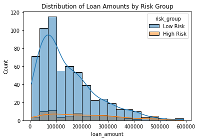

```python
sns.histplot(data=risk_data, x='loan_amount', hue='risk_group', kde=True)
plt.title('Distribution of Loan Amounts by Risk Group')
plt.show()
```

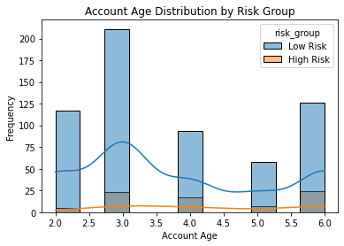

```python
sns.histplot(data=risk_data, x='account_age', hue='risk_group', kde=True)
plt.title('Account Age Distribution by Risk Group')
plt.xlabel('Account Age')
plt.ylabel('Frequency')
plt.show()
```

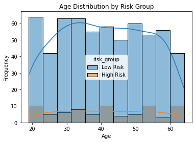

```python
sns.histplot(data=risk_data, x='age', hue='risk_group', kde=True)
plt.title('Age Distribution by Risk Group')
plt.xlabel('Age')
plt.ylabel('Frequency')
plt.show()
```

We have assumed this data is from 1999 instead of 2024 and the factors chosen for the risk_group model are apt to assume if a client is high or low risk.

# 2

## MODEL TO SHOW HOW A LOAN WILL BE COMPLETED (SUPERVISED)

```python
import pandas as pd
import sqlite3
from sklearn.model_selection import train_test_split
from sklearn.linear_model import LogisticRegression
from sklearn.metrics import classification_report, confusion_matrix, accuracy_score
from sklearn.preprocessing import StandardScaler, LabelEncoder
from sklearn.metrics import mean_squared_error, mean_absolute_error, r2_score
import numpy as np
import matplotlib.pyplot as plt


conn = sqlite3.connect('BankRecords.db')


query = """
SELECT l.loan_amount, l.loan_duration, l.loan_payments, l.loan_status,
       t.balance,
       c.birth_number,
       at.a11 as average_salary
FROM loan_table l
JOIN account_table a ON l.account_id = a.account_id
JOIN transaction_table t ON a.account_id = t.account_id
JOIN client_table c ON a.client_id = c.client_id
JOIN a_table at ON c.a1 = at.a1
GROUP BY a.account_id;
"""


data = pd.read_sql_query(query, conn)


data['age'] = data['birth_number'].apply(calculate_age)
data = data.drop(columns=['birth_number'])


le = LabelEncoder()
data['loan_status'] = le.fit_transform(data['loan_status'])


X = data.drop('loan_status', axis=1)
y = data['loan_status']


X_train, X_test, y_train, y_test = train_test_split(X, y, test_size=0.3, random_state=42)


scaler = StandardScaler()
X_train = scaler.fit_transform(X_train)
X_test = scaler.transform(X_test)


model = LogisticRegression()
model.fit(X_train, y_train)


predictions = model.predict(X_test)
print("Accuracy:", accuracy_score(y_test, predictions))
print(classification_report(y_test, predictions))
```

```
Accuracy: 0.7463414634146341
              precision    recall  f1-score   support

           0       0.69      0.71      0.70        66
           1       0.62      0.62      0.62         8
           2       0.79      0.81      0.80       113
           3       0.75      0.50      0.60        18

    accuracy                           0.75       205
   macro avg       0.71      0.66      0.68       205
weighted avg       0.75      0.75      0.74       205
```

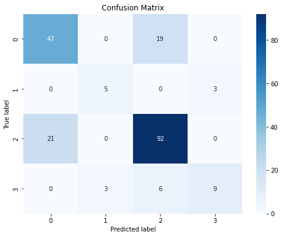

```python
from sklearn.metrics import confusion_matrix



conf_matrix = confusion_matrix(y_test, predictions)

plt.figure(figsize=(8, 6))
sns.heatmap(conf_matrix, annot=True, cmap='Blues')
plt.xlabel('Predicted label')
plt.ylabel('True label')
plt.title('Confusion Matrix')
plt.show()
```

```python
mae = mean_absolute_error(predictions, y_test)

mse = mean_squared_error(y_test, predictions)

rmse = np.sqrt(mse)

r2 = r2_score(y_test, predictions)

print("Mean Absolute Error:", mae)
print("Mean Squared Error:", mse)
print("Root Mean Squared Error:", rmse)
print("R^2 Score:", r2)
```

```
Mean Absolute Error: 0.47804878048780486
Mean Squared Error: 0.926829268292683
Root Mean Squared Error: 0.9627197246824659
R^2 Score: 0.12601534802315661
```

This supervised model uses logistic regression to predict loan status, assuming data accuracy and relevance of selected features, i.e. the loan amount, loan duration and the average salary of where they live. It does this by encoding the letter to a number and trains the model on 70% of the data and tests it on the remaining 30%. The model's performance is measured by accuracy and has an outcome of 74.6%. The model overlooks exact incomes and uses a standard value for the area which might make it inaccurate.

# 3

## Hypothesis Test

Null Hypothesis (H0): There is no correlation with number of inhabitants of an area and the amount of loans they take out

Alternative Hypothesis (H1): There is a correlation with number of inhabitants of an area and the amount of loans they take out

```python
import pandas as pd
import sqlite3
from scipy.stats import pearsonr, t
from scipy.stats import f_oneway
import numpy as np
import seaborn as sns
import matplotlib.pyplot as plt


conn = sqlite3.connect('BankRecords.db')


query = """
SELECT at.a1 as area_id,
    at.a4 as population,
    COUNT(l.loan_id) as total_loans_area
FROM a_table at
JOIN client_table c ON at.a1 = c.a1
JOIN account_table a ON a.client_id = c.client_id
JOIN loan_table l ON l.account_id = a.account_id
GROUP BY at.a1;
"""
data = pd.read_sql_query(query, conn)

data
```

|  | area_id | population | total_loans_area |
| --- | --- | --- | --- |
| 0 | 1 | 1204953 | 79 |
| 1 | 2 | 88884 | 7 |
| 2 | 3 | 75232 | 7 |
| 3 | 4 | 149893 | 6 |
| 4 | 5 | 95616 | 11 |
| ... | ... | ... | ... |
| 72 | 73 | 182027 | 8 |
| 73 | 74 | 323870 | 20 |
| 74 | 75 | 138032 | 3 |
| 75 | 76 | 127369 | 6 |
| 76 | 77 | 148545 | 7 |

77 rows × 3 columns

```python
correlation, p_value = pearsonr(data['population'], data['total_loans_area'])
n = len(data['population'])


t_value = correlation * np.sqrt(n - 2) / np.sqrt(1 - correlation**2)


df = n - 2


critical_value = t.ppf(1 - 0.025, df)

print("T-value:", t_value)
print("Degrees of Freedom:", df)
print("Critical Value", critical_value)
print("Pearson's Correlation Coefficient:", correlation)
print("P-Value:", p_value)
```

```
T-value: 21.687800038178718
Degrees of Freedom: 75
Critical Value 1.9921021536898653
Pearson's Correlation Coefficient: 0.9286960383323025
P-Value: 4.823337817186118e-34
```

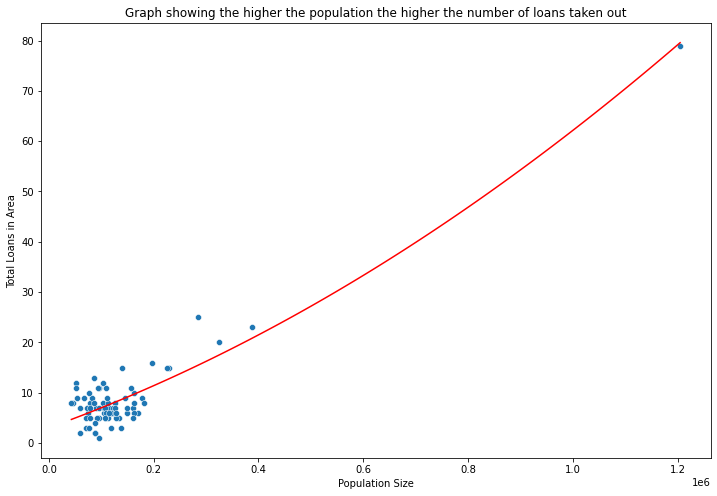

```python
plt.figure(figsize=(12, 8))
sns.scatterplot(data=data, x='population', y='total_loans_area')
degree = 2
coefficients = np.polyfit(data['population'], data['total_loans_area'], degree)
polynomial = np.poly1d(coefficients)
x_values = np.linspace(data['population'].min(), data['population'].max(), 100)
plt.plot(x_values, polynomial(x_values), color='red', label=f'Polynomial Regression (degree={degree})')

plt.xlabel('Population Size')
plt.ylabel('Total Loans in Area')
plt.title('Graph showing the higher the population the higher the number of loans taken out')
plt.show()
```

We can look at the percentage of the population taking out loans, focusing on high-population areas with low loan uptake rates.

```python
query ="""SELECT
    at.a1 as area_id, at.a4 as population,
    COUNT(c.client_id) as total_clients,
    SUM(CASE WHEN l.loan_id IS NOT NULL THEN 1 ELSE 0 END) as clients_with_loan,
    SUM(CASE WHEN l.loan_id IS NULL THEN 1 ELSE 0 END) as clients_without_loan

FROM
    client_table c
LEFT JOIN
    account_table a ON c.client_id = a.client_id
LEFT JOIN
    loan_table l ON l.account_id = a.account_id
LEFT JOIN a_table at ON c.a1 =at.a1
GROUP BY at.a1

    ;
"""
data = pd.read_sql_query(query, conn)

data["clients_with_percentage"] = data["clients_with_loan"]/ data["total_clients"] *100
data["clients_without_percentage"] = data["clients_without_loan"]/ data["total_clients"] *100

data
```

|  | area_id | population | total_clients | clients_with_loan | clients_without_loan | clients_with_percentage | clients_without_percentage |
| --- | --- | --- | --- | --- | --- | --- | --- |
| 0 | 1 | 1204953 | 663 | 79 | 584 | 11.915535 | 88.084465 |
| 1 | 2 | 88884 | 46 | 7 | 39 | 15.217391 | 84.782609 |
| 2 | 3 | 75232 | 63 | 7 | 56 | 11.111111 | 88.888889 |
| 3 | 4 | 149893 | 50 | 6 | 44 | 12.000000 | 88.000000 |
| 4 | 5 | 95616 | 71 | 11 | 60 | 15.492958 | 84.507042 |
| ... | ... | ... | ... | ... | ... | ... | ... |
| 72 | 73 | 182027 | 60 | 8 | 52 | 13.333333 | 86.666667 |
| 73 | 74 | 323870 | 180 | 20 | 160 | 11.111111 | 88.888889 |
| 74 | 75 | 138032 | 56 | 3 | 53 | 5.357143 | 94.642857 |
| 75 | 76 | 127369 | 61 | 6 | 55 | 9.836066 | 90.163934 |
| 76 | 77 | 148545 | 50 | 7 | 43 | 14.000000 | 86.000000 |

77 rows × 7 columns

```python
high_population_threshold = data['population'].quantile(0.75)

high_population_areas = data[data['population'] >= high_population_threshold]

high_population_areas = high_population_areas.sort_values('clients_without_percentage', ascending=False)


(high_population_areas[['area_id', 'population', 'clients_without_percentage', 'clients_with_percentage' ]])
```

|  | area_id | population | clients_without_percentage | clients_with_percentage |
| --- | --- | --- | --- | --- |
| 70 | 71 | 161227 | 89.583333 | 10.416667 |
| 35 | 36 | 159617 | 89.552239 | 10.447761 |
| 42 | 43 | 161854 | 89.090909 | 10.909091 |
| 73 | 74 | 323870 | 88.888889 | 11.111111 |
| 0 | 1 | 1204953 | 88.084465 | 11.915535 |
| 3 | 4 | 149893 | 88.000000 | 12.000000 |
| 25 | 26 | 170449 | 88.000000 | 12.000000 |
| 72 | 73 | 182027 | 86.666667 | 13.333333 |
| 76 | 77 | 148545 | 86.000000 | 14.000000 |
| 71 | 72 | 226122 | 85.576923 | 14.423077 |
| 63 | 64 | 197099 | 85.321101 | 14.678899 |
| 69 | 70 | 285387 | 85.207101 | 14.792899 |
| 53 | 54 | 387570 | 85.161290 | 14.838710 |
| 61 | 62 | 145688 | 84.745763 | 15.254237 |
| 56 | 57 | 161954 | 84.313725 | 15.686275 |
| 46 | 47 | 162580 | 84.126984 | 15.873016 |
| 67 | 68 | 228848 | 82.558140 | 17.441860 |
| 54 | 55 | 157042 | 82.539683 | 17.460317 |
| 13 | 14 | 177686 | 80.000000 | 20.000000 |
| 51 | 52 | 139012 | 79.452055 | 20.547945 |

This model uses hypothesis testing and confirms that higher population areas have increased loan activity. The analysis further highlights areas like Region 71, where despite having a high population, the number of people taking out a loan is low.

# 4

## MODEL TO MAKE HIGH, MEDIUM OR LOW VALUED CLIENTS (UNSUPERVIED)

```python
import pandas as pd
import sqlite3
from sklearn.preprocessing import MinMaxScaler
from sklearn.cluster import KMeans



conn = sqlite3.connect('BankRecords.db')
query = """SELECT
    c.client_id,
    at.a1 as area_id,
    COUNT(t.trans_id) as transaction_count,
    SUM(CASE WHEN t.trans_type = 'Credit' THEN t.trans_amount ELSE 0 END) as total_credit_amount,
    SUM(CASE WHEN t.trans_type = 'Withdrawal' THEN t.trans_amount ELSE 0 END) as total_withdrawal_amount,
    AVG(t.trans_amount) as avg_transaction_amount,
    t.balance,
    COALESCE(l.loan_amount, 0) as loan_amount,
    COALESCE(l.loan_status, 'None') as loan_status,
    COALESCE(ct.card_type, 'None') as card_type,
    at.a11 as average_salary,
    a.creation_date
FROM client_table c
JOIN account_table a ON a.client_id = c.client_id
LEFT JOIN transaction_table t ON a.account_id = t.account_id
LEFT JOIN loan_table l ON a.account_id = l.account_id
LEFT JOIN disposition_table d ON a.account_id = d.account_id
LEFT JOIN card_table ct ON d.disp_id = ct.disp_id
LEFT JOIN a_table at ON c.a1 = at.a1
GROUP BY c.client_id;
"""

data = pd.read_sql_query(query, conn)



data['total_amount'] = data['total_credit_amount'] - data['total_withdrawal_amount']
data['positive_loan_status'] = data['loan_status'].apply(lambda x: 0 if x in ['A', 'C'] else 1)
data['account_age'] = data['creation_date'].apply(calculate_age)


data.drop(['creation_date', 'loan_status'], axis=1, inplace=True)


scaler = MinMaxScaler()
numeric_columns = ['transaction_count', 'total_credit_amount', 'total_withdrawal_amount', 'avg_transaction_amount', 'balance', 'loan_amount', 'total_amount', 'account_age']
data[numeric_columns] = scaler.fit_transform(data[numeric_columns])


kmeans = KMeans(n_clusters=3, random_state=0).fit(data[numeric_columns])
data['value_group'] = kmeans.labels_


value_group_mapping = {0: 'Low Value', 1: 'Medium Value', 2: 'High Value'}
data['value_group'] = data['value_group'].map(value_group_mapping)

data
```

|  | client_id | area_id | transaction_count | total_credit_amount | total_withdrawal_amount | avg_transaction_amount | balance | loan_amount | card_type | average_salary | total_amount | positive_loan_status | account_age | value_group |
| --- | --- | --- | --- | --- | --- | --- | --- | --- | --- | --- | --- | --- | --- | --- |
| 0 | 1 | 18 | 0.171514 | 0.023480 | 0.026057 | 0.035923 | 0.545128 | 0.000000 | None | 8968 | 0.026062 | 1 | 0.50 | Low Value |
| 1 | 2 | 1 | 0.706189 | 0.426832 | 0.388059 | 0.284365 | 0.546822 | 0.137016 | None | 12541 | 0.362175 | 0 | 1.00 | High Value |
| 2 | 4 | 5 | 0.167785 | 0.043890 | 0.035215 | 0.082996 | 0.545128 | 0.000000 | None | 9307 | 0.084921 | 1 | 0.00 | Low Value |
| 3 | 6 | 12 | 0.131991 | 0.023214 | 0.022829 | 0.051610 | 0.541740 | 0.000000 | None | 8754 | 0.039498 | 1 | 0.25 | Low Value |
| 4 | 7 | 15 | 0.055928 | 0.010459 | 0.009873 | 0.056543 | 0.538352 | 0.000000 | None | 9045 | 0.035762 | 1 | 0.00 | Low Value |
| ... | ... | ... | ... | ... | ... | ... | ... | ... | ... | ... | ... | ... | ... | ... |
| 4495 | 13931 | 8 | 0.267711 | 0.222849 | 0.176604 | 0.401229 | 0.507212 | 0.000000 | None | 11277 | 0.321871 | 1 | 0.75 | High Value |
| 4496 | 13955 | 1 | 0.446682 | 0.534030 | 0.502865 | 0.602113 | 0.531576 | 0.710673 | None | 12541 | 0.366537 | 0 | 0.50 | High Value |
| 4497 | 13968 | 61 | 0.275168 | 0.200607 | 0.204081 | 0.344016 | 0.545128 | 0.091439 | classic | 8814 | 0.086604 | 0 | 0.75 | Medium Value |
| 4498 | 13971 | 67 | 0.249814 | 0.089359 | 0.093559 | 0.149505 | 0.545128 | 0.219031 | None | 8110 | 0.042689 | 0 | 0.50 | Low Value |
| 4499 | 13998 | 74 | 0.181954 | 0.179198 | 0.153467 | 0.471077 | 0.512130 | 0.000000 | None | 10673 | 0.212218 | 1 | 0.50 | Low Value |

4500 rows × 14 columns

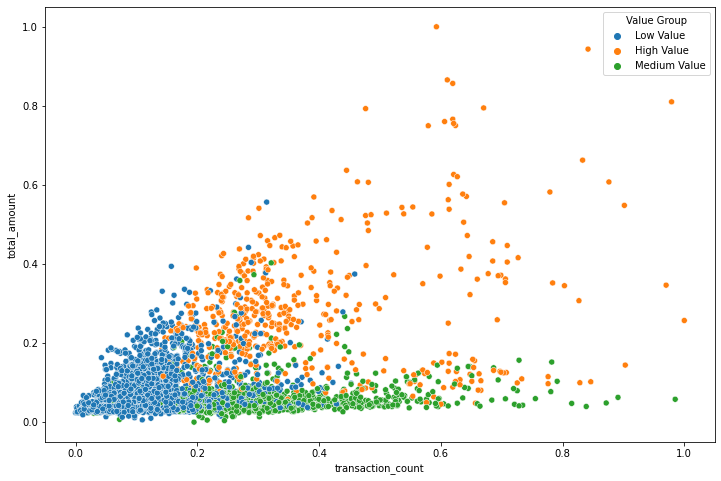

```python
import seaborn as sns
import matplotlib.pyplot as plt

plt.figure(figsize=(12, 8))

sns.scatterplot(data=data, x='transaction_count', y='total_amount', hue='value_group')

plt.legend(title='Value Group')
plt.show()
```

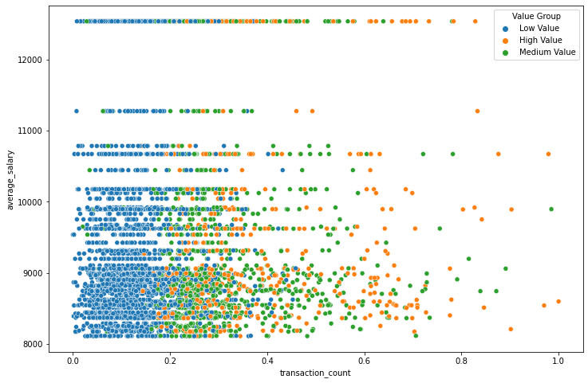

```python
import seaborn as sns
import matplotlib.pyplot as plt

plt.figure(figsize=(12, 8))

sns.scatterplot(data=data, x='transaction_count', y='average_salary', hue='value_group')

plt.legend(title='Value Group')
plt.show()
```

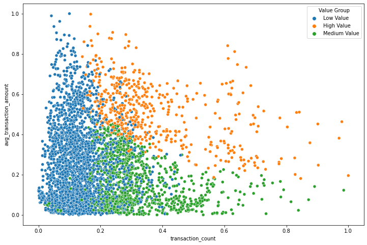

```python
import seaborn as sns
import matplotlib.pyplot as plt

plt.figure(figsize=(12, 8))

sns.scatterplot(data=data, x='transaction_count', y='avg_transaction_amount', hue='value_group')

plt.legend(title='Value Group')
plt.show()
```

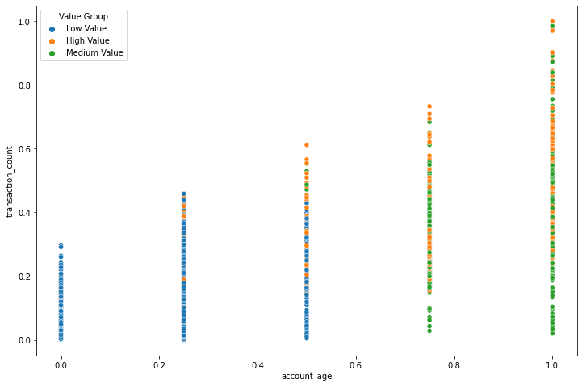

```python
import seaborn as sns
import matplotlib.pyplot as plt

plt.figure(figsize=(12, 8))

sns.scatterplot(data=data, x='account_age', y='transaction_count', hue='value_group')

plt.legend(title='Value Group')
plt.show()
```

This unsupervised model uses K-means clustering to sort clients in high, medium or low value to the bank, assuming the data's accuracy and relevance to the model, I considered the number of transactions, account age, and whether credits exceed withdrawals. The model's performance is not measured using one specific metric but the clusters can be evaluated against customer behaviours and shown graphically. Ethical considerations include avoiding biased interpretations of the clusters that could lead to unfair treatment of certain client groups.

# 5

## ANOVA Test

```python
import pandas as pd
import sqlite3



conn = sqlite3.connect('BankRecords.db')


query = """
SELECT
    t.account_id,
    AVG(t.trans_amount) as trans_amount,
    COALESCE(ct.card_type, 'No Card') as card_type
FROM transaction_table t
LEFT JOIN disposition_table d ON t.account_id = d.account_id
LEFT JOIN card_table ct ON d.disp_id = ct.disp_id
GROUP BY t.account_id;
"""


data = pd.read_sql_query(query, conn)

data
```

|  | account_id | trans_amount | card_type |
| --- | --- | --- | --- |
| 0 | 1 | 1569.767782 | No Card |
| 1 | 2 | 6593.052929 | No Card |
| 2 | 3 | 2521.553846 | No Card |
| 3 | 4 | 1886.943011 | No Card |
| 4 | 5 | 1986.683333 | No Card |
| ... | ... | ... | ... |
| 4495 | 11333 | 8955.966033 | No Card |
| 4496 | 11349 | 13017.671711 | No Card |
| 4497 | 11359 | 7799.157143 | classic |
| 4498 | 11362 | 3866.309593 | No Card |
| 4499 | 11382 | 10368.228854 | No Card |

4500 rows × 3 columns

```python
from scipy.stats import f_oneway


gold_trans = data[data['card_type'] == 'gold']['trans_amount']
classic_trans = data[data['card_type'] == 'classic']['trans_amount']
junior_trans = data[data['card_type'] == 'junior']['trans_amount']
no_trans = data[data['card_type'] == 'No Card']['trans_amount']


anova_result = f_oneway(gold_trans, classic_trans, junior_trans, no_trans )


print("F-Statistic:", anova_result.statistic)
print("P-Value:", anova_result.pvalue)
```

```
F-Statistic: 209.8331174381417
P-Value: 2.1894346882170062e-127
```

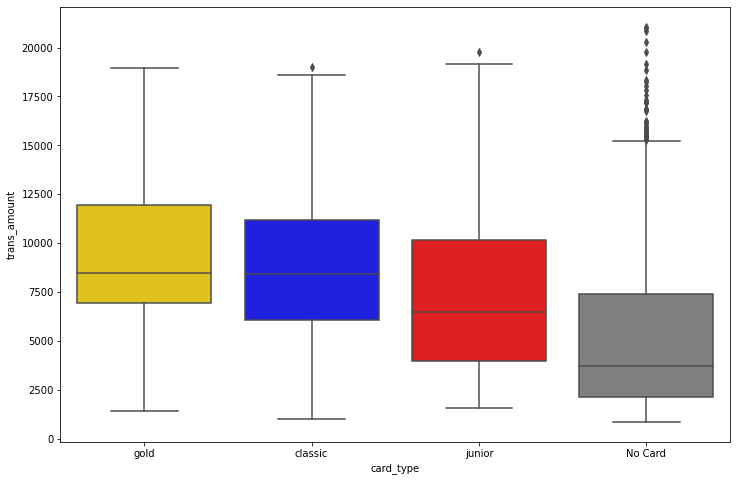

```python
import seaborn as sns
import matplotlib.pyplot as plt

plt.figure(figsize=(12, 8))
order = ['gold', 'classic', 'junior', 'No Card']
palette = {
    'gold': 'gold',
    'classic': 'blue',
    'junior': 'red',
    'No Card': 'grey'
}
sns.boxplot(data=data, x='card_type', y='trans_amount', order=order, palette=palette)

plt.show()
```

This model uses ANOVA testing and statistical analysis to explore the differences between card type and the average transaction amount by extracting that data from the database. The model starts by averaging the transaction amount per account and labelling those without cards as 'No Card'. The ANOVA technique was chosen for its ability to compare values across multiple groups and it indicates significant variance in spending by card type, with the F-statistic and p-value supporting this conclusion. The test shows a p-value of 2.1894346882170062e-127 which is very low. This would imply there are significant disparities.

## Task 4: Experimental Results and Analysis (25 Marks)

Given the **five** modelling solutions implemented above, analyse, discuss and present your findings to the key stakeholders of the bank.

Your answer should clearly cover the following:

- Present your findings in a clear and concise manner;
- Discuss your results in the context of the selected solution;
- Discuss how these results can help the bank in performing customer risk assessment and establishing customer retention strategies;
- Present the limitations (if any) of your solutions in a clear and concise manner.

**World Limit**: 500 words. This limit applies only to the explanations. There is no limit on any associated code or figures.

**Write your answer here (text cell(s) to be used, as appropriate)**

### 1. Hypothesis Test on if there is a difference between the distribution of the amount a low risk customer takes out as a loan and a high risk customer takes out as a loan

The hypothesis test distinguishes between loan amounts for low and high-risk customers, with a significant t-statistic and low p-value, suggesting differentiation. This insight enables the bank to identify clients that need their financial services improving client retention and lending efficiency. However, the model is not reliant on a lot of factors and perhaps by including more it could be improved.

We can also see from the figures below the distribution of low and high risk groups on varying factors which can help the bank identify further who will require financial services.

##### Figure 1.1

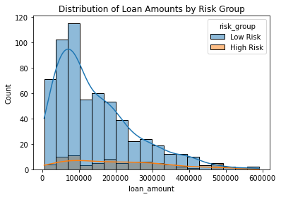

##### Figure 1.2

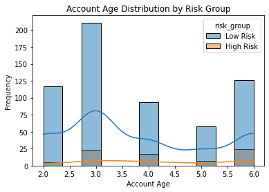

##### Figure 1.3

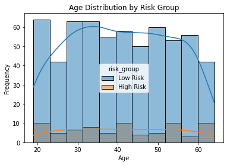

### 2. MODEL TO SHOW HOW A LOAN WILL BE COMPLETED (SUPERVISED)

##### Figure 2.1

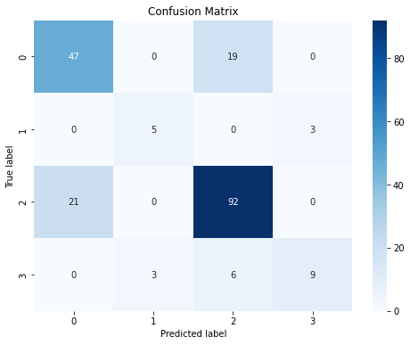

### 3. Hypothesis test to see if there is a correlation with number of inhabitants of an area and the amount of loans they take out

This hypothesis test looks at the correlation between the population of an area and the number of loans they take out. As we can see from the low p-value (4.823337817186118e-34) and the Pearson correlation we rejected the null hypothesis. We can see this trend in Figure 3.1. For further analysis I looked at areas with a high population but lower loan uptake, this is shown in Figure 3.2. Area 71 represents an untapped market. The bank can use this data to target these areas for growth. This model is limited by just taking the population as a factor and overlooking the socio-economic factors that influence the amount of loans taken out in an area.

##### Figure 3.1

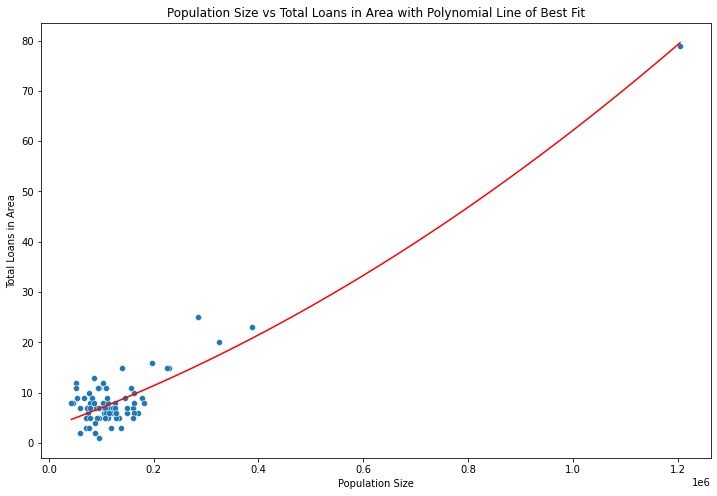

##### Figure 3.2

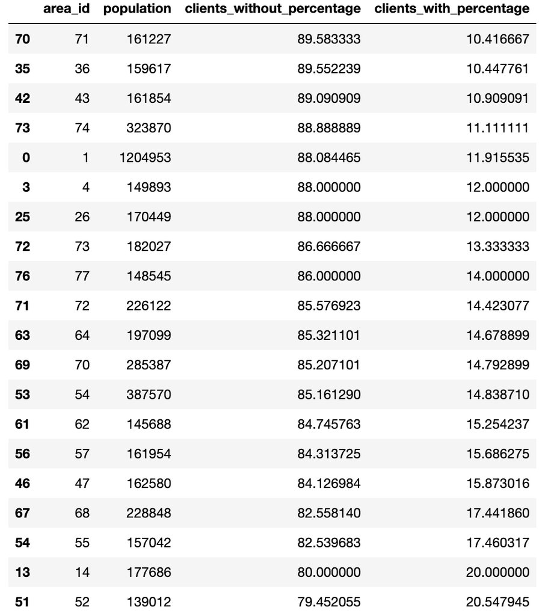

### 4. MODEL TO MAKE HIGH, MEDIUM OR LOW VALUED CLIENTS (UNSUPERVIED)

The unsupervised K-Means model sorts clients into high, medium, or low values based on a variety of factors. This will allow the bank to tailor personalised services to each group. For example, high-value customers can get perks from the bank to increase customer retention. However, the model may not account for all the factors that influence customer behaviour.

I used visual scatterplots (Figures 4.1, 4.2, 4.3 and 4.4) to visualise the clusters to help the bank but all these scatterplots use transaction_count which might not make them as insightful as using other factors. Future models could integrate broader behavioural indicators.

##### Figure 4.1

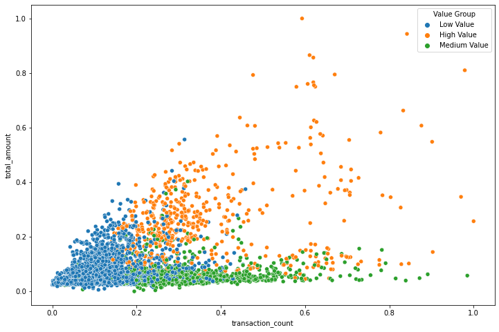

##### Figure 4.2

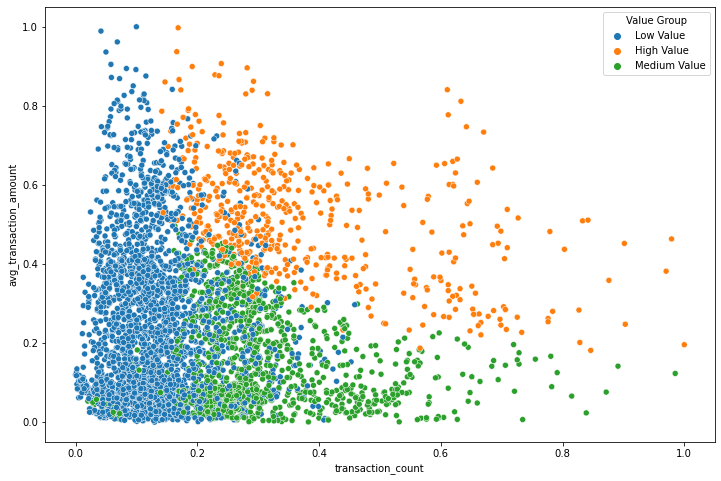

##### Figure 4.3

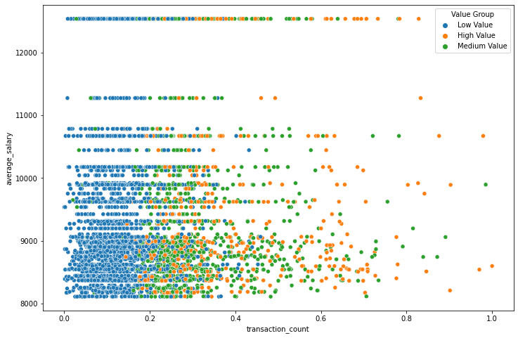

##### Figure 4.4

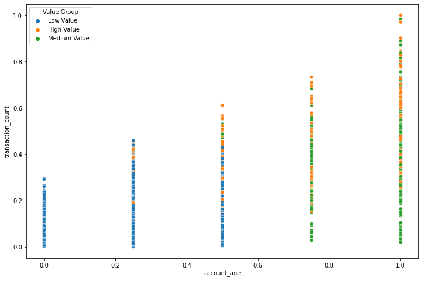

### 5. ANOVA Test on Card Types and Average Transaction amount

The ANOVA test on card types reveals significant differences in transaction amounts. This is shown by the significant F-statistic and extremely low p-value rejecting the null hypothesis. Gold cardholders transact higher amounts on average as shown in Figure 5.1. This information can be used by the bank potentially to upgrade people from lower cards to higher cards, and offer cards to those who do not currently have one. This model does not include external factors that affect spending and the bank should consider the ethical implications of giving preferred treatment based on card type.

#### Figure 5.1

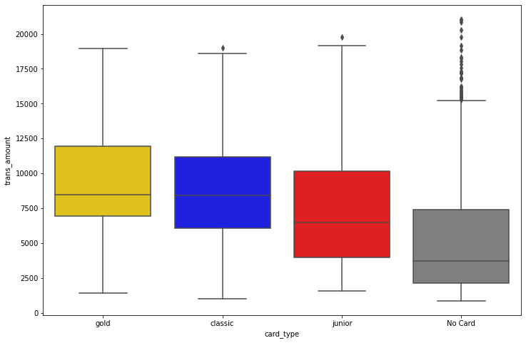

## Task 5: Conclusion (10 Marks)

Given the insights derived from Tasks 1-4, provide a conclusion that clearly covers the following:

- A summary of the main points;
- A discussion of the significance of your results;
- Any recommendation(s) resulting from your analysis;
- Any overall ethical considerations arising from the data analysis of this business domain.

**World Limit**: 300 words.

**Write your answer here (text cell(s) to be used, as appropriate)**

Throughout tasks 1-4 I provided a comprehensive domain analysis for the bank, demonstrating how data science can derive meaningful insights from the dataset. The analysis performed on the data showed invaluable insights for the bank to help with customer retention and minimise the risks. The main points included creating a normalised database based on an Entity-Relationship model, employing a wide range of complex data science techniques for risk assessment, analysing spending patterns and customer segmentation.

The significance of these results lies in their impact on the bank, particularly in enhancing customer retention and minimising risks. The ability to put clients into risk groups aids the bank in creating new strategies to help clients and minimise risk when offering services like loans. The customer segmentation model allows for a more personalised service and aims to improve customer satisfaction and retention. The insight into spending patterns based on card type helps the bank to tailor the products it offers to a range of clients.

Recommendations from this analysis suggest that the bank should continue to use data science to refine its strategies as the models presented do have room for improvement, perhaps with the addition of more detailed data. This would help them further with client retention and risk management.

However, the bank has to uphold ethical considerations. They must not discriminate from the data leading to biased decisions, making the treatment of clients unfair. It must tell clients what data it knows about them and how it is being used. This will maintain trust and minimise the loss of clients.

In conclusion, the integration of data science into the bank's operations offers significant benefits in understanding client needs, managing risks, and enhancing the overall quality of the bank. However, this must be balanced with ethical considerations to uphold the bank's reputation.

## Overall Academic Quality (10 Marks)

10 marks are allocated for the clarity and cohesiveness of your answers (both text and code) across all tasks with appropriate, relevant and effective analysis and presentation of the results.

## Deliverables

You should submit the following to the submission point on the teaching portal:

1. the SQLite database produced in Task 2;
2. the completed Jupyter notebook (both .ipynb and HTML files) that also includes the SQL statements (Task 2), the research design and its implementation (Task 3), and the analysis and presentation of your results (Task 4);
3. any figures or diagrams that are included in your answers in the Jupyter notebook.

For each task where text is required, we have provided guidelines above on the suggested word counts. Exceeding the word count will result in any work beyond the word count being disregarded when assessing.